# Section 10: K-Nearest Neighbors

Pablo Arés Gastesi

2026-07-07

# 1 Introduction

Every method we have studied so far — linear/logistic regression, LDA/QDA, trees — fits some kind of global model: a formula, a set of coefficients, a sequence of splits. **K-Nearest Neighbors (KNN)** does none of that. It is a *lazy* algorithm: at training time it does nothing except store the training data, and all the work happens when a new point needs a prediction.

The idea is simple: to predict the value (regression) or class (classification) of a new point $x_0$, find the $k$ training points closest to $x_0$ and combine their responses — average them for regression, take a majority vote for classification. KNN makes no assumption about the shape of the relationship between predictors and response, which makes it flexible, but also means it has no compact summary (no coefficients, no tree diagram) to inspect once fitted.

We cover KNN regression first, then classification, and along the way discuss two ideas that matter for *any* flexible model: the bias-variance trade-off and the distinction between parameters and hyperparameters.

Further reading: [ISLR2 Section 2.2.3 and Section 4.7.5](https://www.statlearning.com/) cover KNN regression and classification respectively.

# 2 KNN regression

## 2.1 The idea, with a toy example

Suppose we have training data of pairs $(x, y)$, where $x$ is the predictor and $y$ the response, and we fix a number of neighbors $k$. Given a new value $x_{\text{new}}$, we find the $k$ training points whose $x$-values are closest to $x_{\text{new}}$, and predict the **average** of their $y$-values. Writing $x_{(1)}, \ldots, x_{(k)}$ for those $k$ nearest points,

$$\hat y_{\text{new}} = \frac{1}{k}\left(y_{(1)} + y_{(2)} + \cdots + y_{(k)}\right)$$

Take the training set $\{(1,2), (2,4.2), (3,3), (4,5), (5,8)\}$ and suppose we want to predict $y$ at $x = 1.7$ with $k = 2$.

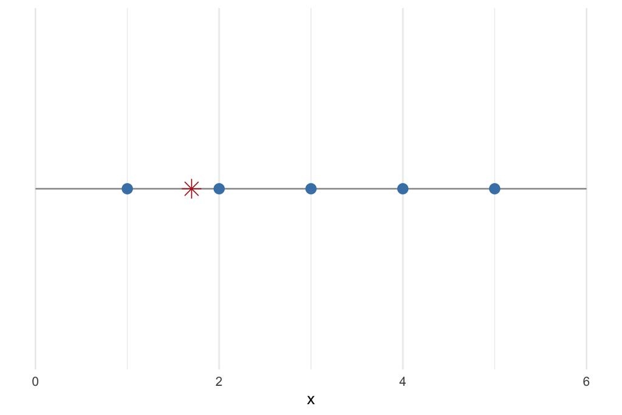

Figure 2.1: Training set values of x (blue) and the new point x = 1.7 (red star). Only the x-axis distance matters for KNN regression with a single predictor.

```r
toy <- data.frame(x = 1:5, y = c(2, 4.2, 3, 5, 8))
new_x <- 1.7

ggplot() +
  geom_segment(aes(x = 0, xend = 6, y = 1, yend = 1), colour = "grey60") +
  geom_point(data = toy, aes(x = x, y = 1), size = 3, colour = "steelblue") +
  geom_point(aes(x = new_x, y = 1), shape = 8, size = 4, colour = "firebrick") +
  scale_y_continuous(limits = c(0.9, 1.1), breaks = NULL) +
  labs(x = "x", y = NULL) +
  theme_minimal()
```

The two nearest points to $x = 1.7$ are $x = 1$ and $x = 2$, so the prediction is

$$\hat y = \frac{1}{2}(y_1 + y_2) = \frac{1}{2}(2 + 4.2) = 3.1$$

## 2.2 Fitting with `knnreg()` and visualising the prediction function

`caret::knnreg()` fits exactly this model. Predicting over a fine grid of $x$-values traces out the whole prediction function, which is a **step function** — it can only ever produce a small number of distinct predicted values (one per possible neighborhood), and it jumps every time the set of $k$ nearest neighbors changes.

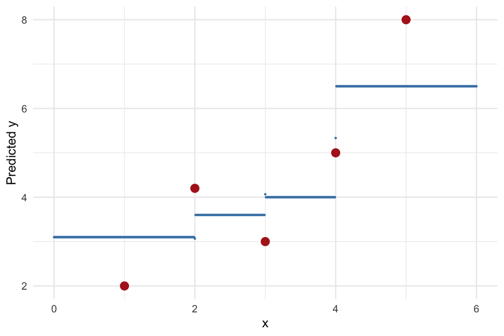

Figure 2.2: KNN regression prediction function, k = 2

```r
modelo.knn <- knnreg(y ~ x, data = toy, k = 2)
x.new <- seq(from = 0, to = 6, by = 0.01)
prediction.frame <- data.frame(x = x.new)
prediction.frame$y.new <- predict(modelo.knn, newdata = prediction.frame)

ggplot(prediction.frame, aes(x = x, y = y.new)) +
  geom_point(size = 0.3, colour = "steelblue") +
  geom_point(data = toy, aes(x = x, y = y), size = 3, colour = "firebrick") +
  labs(x = "x", y = "Predicted y") +
  theme_minimal()
```

Look carefully at the flat segments: around $x = 2, 3, 4$ something different happens compared to the tails, because those points sit *between* two other training points rather than at one extreme — their neighborhood changes more often as $x$ moves. With $k = 3$ the function is smoother (averaging over more points softens the jumps), but still piecewise constant:

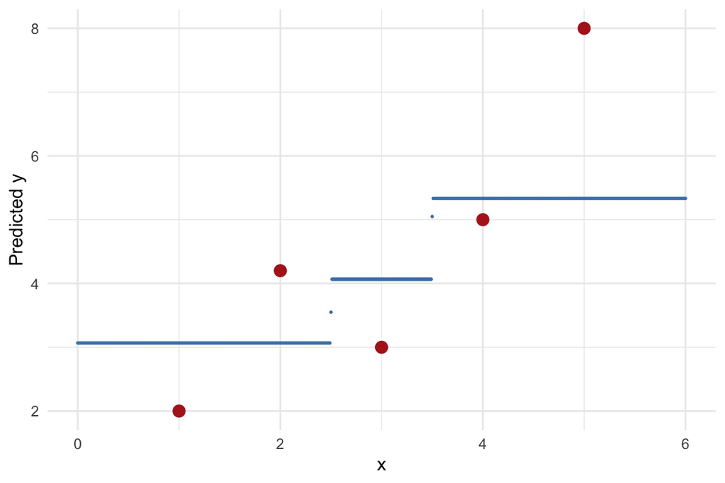

Figure 2.3: KNN regression prediction function, k = 3

```r
modelo.knn <- knnreg(y ~ x, data = toy, k = 3)
prediction.frame$y.new <- predict(modelo.knn, newdata = prediction.frame)

ggplot(prediction.frame, aes(x = x, y = y.new)) +
  geom_point(size = 0.3, colour = "steelblue") +
  geom_point(data = toy, aes(x = x, y = y), size = 3, colour = "firebrick") +
  labs(x = "x", y = "Predicted y") +
  theme_minimal()
```

This is a fundamental difference from linear regression: KNN never extrapolates a smooth trend, it just averages whatever training points happen to be nearby.

# 3 Comparing regression models: penguins

We now move to a real dataset with several predictors: the Palmer Penguins data, predicting **flipper length** from bill length, bill depth, and body mass. We compare three models we already know how to fit — linear regression and a regression tree — against KNN regression.

```r
penguins <- na.omit(as.data.frame(palmerpenguins::penguins))

modelo.lineal <- lm(flipper_length_mm ~ bill_length_mm + bill_depth_mm + body_mass_g,
                    data = penguins)
modelo.tree   <- rpart(flipper_length_mm ~ bill_length_mm + bill_depth_mm + body_mass_g,
                       data = penguins)
modelo.knn    <- knnreg(flipper_length_mm ~ bill_length_mm + bill_depth_mm + body_mass_g,
                        data = penguins, k = 5)

predict.linear <- predict(modelo.lineal, newdata = penguins)
predict.tree   <- predict(modelo.tree,   newdata = penguins)
predict.knn    <- predict(modelo.knn,    newdata = penguins)

cat("MSE, linear model:  ", mean((penguins$flipper_length_mm - predict.linear)^2), "\n")
```

```
## MSE, linear model:   32.96876
```

```r
cat("MSE, tree:          ", mean((penguins$flipper_length_mm - predict.tree)^2), "\n")
```

```
## MSE, tree:           28.12864
```

```r
cat("MSE, KNN (k = 5):   ", mean((penguins$flipper_length_mm - predict.knn)^2), "\n")
```

```
## MSE, KNN (k = 5):    29.74014
```

All three are in the same ballpark, with the tree slightly ahead here. But these are all *training* errors — before drawing any conclusion we need to know what happens as $k$ changes, and, more importantly, what happens on data the model hasn’t seen.

## 3.1 The danger of judging k from training error alone

```r
mse.vector <- vector(mode = "double", length = 10)
for (i in 1:10) {
  modelo.knn_i  <- knnreg(flipper_length_mm ~ bill_length_mm + bill_depth_mm + body_mass_g,
                          data = penguins, k = i)
  prediccion.knn <- predict(modelo.knn_i, newdata = penguins)
  mse.vector[i] <- round(mean((penguins$flipper_length_mm - prediccion.knn)^2), 5)
}
data.frame(Neighbors = 1:10, Training_MSE = mse.vector)
```

| Neighbors | Training_MSE |
| --- | --- |
| 1 | 0.00000 |
| 2 | 15.97347 |
| 3 | 21.62533 |
| 4 | 26.77228 |
| 5 | 29.74014 |
| 6 | 31.21946 |
| 7 | 32.15429 |
| 8 | 33.62865 |
| 9 | 34.20204 |
| 10 | 34.38525 |

$k = 1$ gives the lowest training MSE — essentially zero — which is exactly what we should expect and exactly what should worry us: with $k=1$, every point is predicted using *itself* as its own nearest neighbor, so the fit is almost perfect by construction. This says nothing about how the model will do on new data; it is the same overfitting story we’ve already seen with unconstrained trees and high-degree polynomials, just in a new disguise.

## 3.2 Choosing k properly: a train/test split

```r
set.seed(1)
test.lines <- sample(1:nrow(penguins), 33, replace = FALSE)
train.set  <- penguins[-test.lines, ] %>%
  select(flipper_length_mm, bill_length_mm, bill_depth_mm, body_mass_g)
test.set   <- penguins[test.lines, ] %>%
  select(flipper_length_mm, bill_length_mm, bill_depth_mm, body_mass_g)

mse.test.vector <- vector(mode = "double", length = 10)
for (i in 1:10) {
  modelo.knn_i   <- knnreg(flipper_length_mm ~ bill_length_mm + bill_depth_mm + body_mass_g,
                           data = train.set, k = i)
  prediccion.knn <- predict(modelo.knn_i, newdata = test.set)
  mse.test.vector[i] <- round(mean((test.set$flipper_length_mm - prediccion.knn)^2), 5)
}
data.frame(Neighbors = 1:10, Test_MSE = mse.test.vector)
```

| Neighbors | Test_MSE |
| --- | --- |
| 1 | 58.90909 |
| 2 | 42.55892 |
| 3 | 34.08102 |
| 4 | 36.69380 |
| 5 | 38.12908 |
| 6 | 41.61405 |
| 7 | 44.71456 |
| 8 | 43.14799 |
| 9 | 44.63431 |
| 10 | 43.44982 |

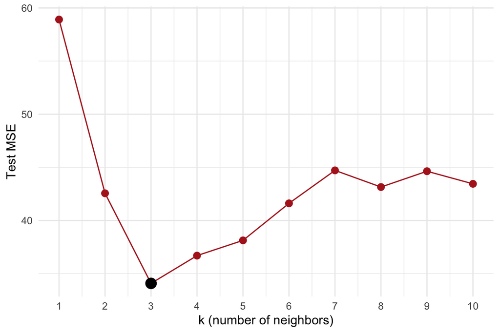

Figure 3.1: Test MSE vs. number of neighbors — the U-shape typical of a bias-variance trade-off

```r
mse_df <- data.frame(k = 1:10, Test_MSE = mse.test.vector)

ggplot(mse_df, aes(x = k, y = Test_MSE)) +
  geom_line(colour = "firebrick") +
  geom_point(colour = "firebrick", size = 2.5) +
  geom_point(data = mse_df[which.min(mse_df$Test_MSE), ], size = 4, colour = "black") +
  scale_x_continuous(breaks = 1:10) +
  labs(x = "k (number of neighbors)", y = "Test MSE") +
  theme_minimal()
```

The picture is completely different from the training-error version: $k = 1$ is now one of the *worst* choices, and the best test performance is around $k = 3$ (black dot). This is the pattern to remember — training error keeps improving (or staying flat) as $k \to 1$, while test error traces out a U-shape, because very small $k$ overfits (high variance) and very large $k$ oversmooths (high bias, since the neighborhood eventually covers most of the data regardless of where the new point is).

# 4 The bias-variance trade-off

Every model we fit carries two sources of error. **Variance** is how much the fitted model would change if we trained it on a different sample from the same population — a model that tracks the training data very closely (e.g. $k=1$) will look quite different if even a few training points change, so it has high variance. **Bias** is the error introduced by approximating a complicated reality with a simpler model — averaging over many neighbors (large $k$) smooths away real local structure, introducing bias even though the prediction barely changes from one training sample to the next.

As a rule of thumb: simple/inflexible models (large $k$, low-degree polynomials, shallow trees) have **low variance, high bias**; complex/flexible models (small $k$, high-degree polynomials, deep trees) have **high variance, low bias**. Neither extreme is generally best — the goal is to find the point that minimizes their sum, which is exactly what the U-shaped test MSE curve above is tracing out.

A separate consideration, orthogonal to accuracy, is **interpretability**. A model can predict well and still be a “black box” whose decisions are hard to explain — which matters a great deal when a prediction needs to be justified to a patient, a regulator, or a court. KNN sits close to the black-box end: unlike a tree or a regression equation, there is no compact summary of *why* a given prediction was made beyond “these were the nearest neighbors.”

# 5 Parameters and hyperparameters

A **parameter** is a quantity estimated from the data that the model uses internally to make predictions — e.g. the slope of a fitted regression line. The number of neighbors $k$ is different: it is not estimated from the data but *chosen* by us before fitting, as an input to the algorithm. We say $k$ is a **hyperparameter**: something that controls how the model makes predictions without being estimated by the fitting procedure itself. Model selection — choosing $k$, the degree of a polynomial, or the complexity parameter of a tree — is really the problem of choosing good hyperparameters, and (as above) this should always be done using test error or cross-validation, never training error.

# 6 To scale or not to scale

KNN predictions depend entirely on **distances**, which makes the scale of the predictors matter enormously. Suppose we model salary and age jointly, with age in years and salary in euros/year. Consider three people: $p_1 = (\text{age}=50, \text{salary}=45{,}000)$, $p_2 = (75, 45{,}000)$, $p_3 = (50, 45{,}500)$.

```r
d_p1_p2 <- sqrt((75 - 50)^2 + (45000 - 45000)^2)
d_p1_p3 <- sqrt((50 - 50)^2 + (45500 - 45000)^2)
cat("Euclidean distance p1-p2 (25-year age gap):  ", d_p1_p2, "\n")
```

```
## Euclidean distance p1-p2 (25-year age gap):   25
```

```r
cat("Euclidean distance p1-p3 (500-euro pay gap): ", d_p1_p3, "\n")
```

```
## Euclidean distance p1-p3 (500-euro pay gap):  500
```

By raw Euclidean distance, $p_3$ is 20 times “farther” from $p_1$ than $p_2$ is — even though a 500-euro difference in annual salary is trivial while a 25-year age gap is not. Left unscaled, KNN would essentially ignore age and let salary dominate every distance calculation. Neither `class::knn()` nor `caret::knnreg()` standardize predictors automatically, so this is on us: before fitting, rescale so every predictor has mean 0 and standard deviation 1 with `scale()`. We do exactly this in the Caravan example below, where the 85 predictors are on wildly different scales.

# 7 KNN for classification

## 7.1 The idea

The classification version replaces averaging with a **majority vote**: given a new point $x_0$, find its $k$ nearest neighbors and predict the most common class among them. For example, with $k = 5$ and neighbors coloured blue, blue, red, blue, green, the prediction is blue (3 out of 5 votes).

## 7.2 A first example: iris species

```r
set.seed(123)
size <- nrow(iris)
idx  <- sample(1:size, size = 100)

train  <- iris[1:size %in% idx, 1:4]
test   <- iris[!1:size %in% idx, 1:4]
labels <- iris[1:size %in% idx, 5]

fit <- knn(train, test, labels)
plot.df <- data.frame(test, predicted = fit)
```

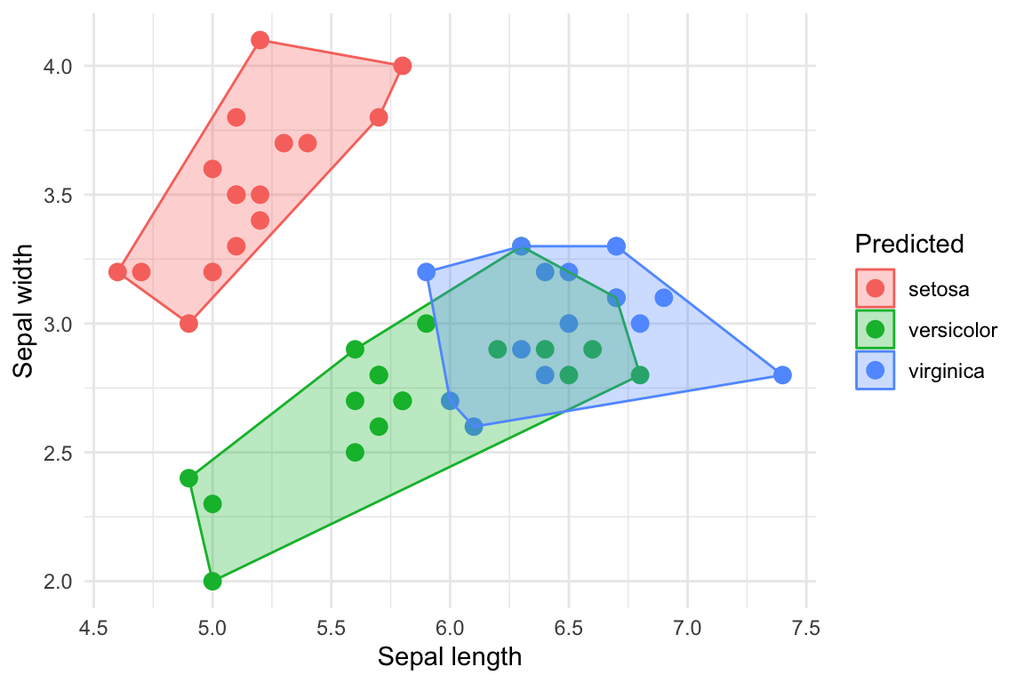

Figure 7.1: Predicted iris species (k = 1, default) with convex hulls per predicted class

```r
plot.df1 <- data.frame(x = plot.df$Sepal.Length,
                       y = plot.df$Sepal.Width,
                       predicted = plot.df$predicted)

boundary <- plot.df1 %>%
  group_by(predicted) %>%
  slice(chull(x, y))

ggplot(plot.df, aes(Sepal.Length, Sepal.Width, colour = predicted, fill = predicted)) +
  geom_point(size = 3) +
  geom_polygon(data = boundary, aes(x, y), alpha = 0.3) +
  labs(x = "Sepal length", y = "Sepal width", colour = "Predicted", fill = "Predicted") +
  theme_minimal()
```

```r
misclass.vector <- vector(mode = "double", length = 10)
for (i in 1:10) {
  fit_i <- knn(train, test, labels, k = i)
  misclass.vector[i] <- mean(fit_i != iris[!1:size %in% idx, 5]) * 100
}
data.frame(Neighbors = 1:10, Misclassification_pct = misclass.vector)
```

| Neighbors | Misclassification_pct |
| --- | --- |
| 1 | 4 |
| 2 | 4 |
| 3 | 4 |
| 4 | 4 |
| 5 | 4 |
| 6 | 4 |
| 7 | 4 |
| 8 | 4 |
| 9 | 4 |
| 10 | 2 |

Using all four measurements (not just the two plotted above), iris species are separated cleanly enough that misclassification tends to stay low and fairly insensitive to $k$ over this range — a real contrast with the Caravan example below, where $k$ matters a great deal. One practical warning worth carrying forward: an earlier version of this loop had a one-line copy-paste bug — a duplicated `fit <-` call silently re-ran `knn()` with its default `k = 1` right after the correct `k = i` call, so every row of the resulting table came out identical regardless of `i`. If a table like this ever looks suspiciously constant, that is the first thing to check before concluding “$k$ doesn’t matter here.”

## 7.3 Class imbalance and the “accuracy paradox”: Caravan insurance

The `Caravan` dataset (`ISLR2`) records whether 5,822 customers purchased caravan insurance (`Purchase`), along with 85 demographic predictors.

```r
dim(Caravan)
```

```
## [1] 5822   86
```

```r
cat("Overall purchase rate:", round(sum(Caravan$Purchase == "Yes") * 100 / nrow(Caravan), 2), "%\n")
```

```
## Overall purchase rate: 5.98 %
```

```r
summary(Caravan$Purchase)
```

```
##   No  Yes
## 5474  348
```

Only about 6% of customers buy the policy — a strongly **imbalanced** classification problem. We standardize the 85 predictors, hold out the first 1,000 customers as a test set, and fit KNN with $k = 1$ on the rest.

```r
my.data      <- scale(Caravan[, -86])
data.train   <- my.data[1001:nrow(my.data), ]
data.test    <- my.data[1:1000, ]
labels.train <- Caravan$Purchase[1001:nrow(Caravan)]
labels.test  <- Caravan$Purchase[1:1000]

knn.caravan <- knn(data.train, data.test, labels.train, k = 1)
cat("Misclassification rate:      ", round(mean(labels.test != knn.caravan) * 100, 1), "%\n")
```

```
## Misclassification rate:       11.8 %
```

```r
cat("Rate if we always guess 'No':", round(mean(labels.test != "No") * 100, 1), "%\n")
```

```
## Rate if we always guess 'No': 5.9 %
```

```r
table.knn <- table(knn.caravan, labels.test)
table.knn
```

```
##            labels.test
## knn.caravan  No Yes
##         No  873  50
##         Yes  68   9
```

```r
n_pred_yes <- table.knn["Yes", "No"] + table.knn["Yes", "Yes"]
success_rate <- round(table.knn["Yes", "Yes"] * 100 / n_pred_yes, 2)
cat("Customers the model flagged as buyers:", n_pred_yes, "\n")
```

```
## Customers the model flagged as buyers: 77
```

```r
cat("Of those, actual buyers:              ", table.knn["Yes", "Yes"], "\n")
```

```
## Of those, actual buyers:               9
```

```r
cat("Success rate among flagged customers: ", success_rate, "%\n")
```

```
## Success rate among flagged customers:  11.69 %
```

## 7.4 Sweeping k: accuracy vs. usefulness

```r
purchase.vector <- vector(mode = "double", length = 10)
mean.vector     <- vector(mode = "double", length = 10)
yes.vector      <- vector(mode = "double", length = 10)

for (i in 1:10) {
  knn.caravan_i <- knn(data.train, data.test, labels.train, k = i)
  table_i <- table(knn.caravan_i, labels.test)
  purchase.vector[i] <- round(table_i["Yes", "Yes"] * 100 /
                                (table_i["Yes", "No"] + table_i["Yes", "Yes"]), 2)
  mean.vector[i] <- round(mean(labels.test != knn.caravan_i) * 100, 1)
  yes.vector[i]  <- table_i["Yes", "Yes"]
}

data.frame(Neighbors = 1:10,
          Wrong_guesses_pct = mean.vector,
          Purchase_success_pct = purchase.vector,
          Correct_purchases_flagged = yes.vector)
```

| Neighbors | Wrong_guesses_pct | Purchase_success_pct | Correct_purchases_flagged |
| --- | --- | --- | --- |
| 1 | 11.5 | 13.16 | 10 |
| 2 | 10.5 | 8.93 | 5 |
| 3 | 7.4 | 20.00 | 5 |
| 4 | 7.0 | 28.00 | 7 |
| 5 | 6.6 | 26.67 | 4 |
| 6 | 6.2 | 36.36 | 4 |
| 7 | 6.2 | 28.57 | 2 |
| 8 | 5.8 | 66.67 | 2 |
| 9 | 5.8 | 100.00 | 1 |
| 10 | 5.8 | 100.00 | 1 |

As $k$ grows, overall accuracy improves (fewer wrong guesses) — but the model becomes *more conservative* about predicting “Yes”, so it flags fewer and fewer customers. At $k = 9$ and $k = 10$ the “success rate” hits 100%, which sounds perfect, but the model is only flagging a single customer as a prospective buyer, and getting lucky. A 100% success rate on one customer is not a business strategy — this is the same small-sample trap as an outstanding batting average over three at-bats: impressive-looking numbers that carry almost no information, purely because the base is so small.

# 8 Summary

- KNN is simple and easy to reason about, but it degrades badly as the number of predictors grows: in high dimensions, distances between points tend to become similar to one another, so “nearest neighbor” stops being a meaningful concept (the **curse of dimensionality**).
- Small $k$ gives a flexible, low-bias, high-variance model (risk of overfitting); large $k$ gives a smoother, high-bias, low-variance model (risk of oversmoothing). This is a specific instance of the general bias-variance trade-off that governs every model in this course.
- $k$ is a hyperparameter, not a parameter — it must be chosen using test error or cross-validation, never training error, which is misleadingly optimistic (best, and often near-zero, at $k = 1$).
- Predictors should be standardized (`scale()`) before running KNN unless they are already on comparable scales, since the algorithm relies directly on distances.
- With imbalanced classes, raw accuracy can be a misleading metric — compare against the “always predict the majority class” baseline, and consider a metric tied to the actual decision being made (e.g. precision among flagged cases).

| Concept | Function | Notes |
| --- | --- | --- |
| KNN regression | `knnreg()` (`caret`) | predicts the mean response of the k nearest neighbors |
| KNN classification | `knn()` (`class`) | predicts the majority class among the k nearest neighbors |
| Standardize predictors | `scale()` | mean 0, sd 1 for every column; essential for distance-based methods |
| Confusion matrix | `table(predicted, actual)` | needed to look past overall accuracy under class imbalance |

Key takeaway: KNN makes no assumption about the functional form linking predictors to response, trading that flexibility for sensitivity to $k$, to the scale of the predictors, and to the number of predictors — three knobs that, unlike a regression coefficient or a tree split, are entirely in the analyst’s hands.